# Results - FHIR Review

Lehne, Vorisek

09-06-2021

# Network Analysis

First, load relevant packages for the network analysis:

```r
library(tidyverse)
library(igraph)
library(ggraph)
library(visNetwork)
```

Read in the articles (“articles.csv” was exported from Rayyan):

```r
articles <- read_csv("articles.csv")
head(articles)
```

```
## # A tibble: 6 x 19
##   key    title   year month   day journal issn  volume issue pages authors url
##   <chr>  <chr>  <dbl> <dbl> <dbl> <chr>   <chr>  <dbl> <dbl> <chr> <chr>   <chr>
## 1 rayya… Autom…  2019    NA    NA Studie… 1879…    258    NA 11-15 Lacker… http…
## 2 rayya… FHIRC…  2019    NA    NA AMIA J… 2153…   2019    NA 54-63 Metke-… http…
## 3 rayya… Integ…  2020    10     7 Journa… 1438…     22    10 e198… Gruend… http…
## 4 rayya… FHIR …  2020     3    11 BMC me… 1472…     20     1 53    Xu H a… http…
## 5 rayya… Devel…  2020     3    NA JCO cl… 2473…      4    NA 201-… Zong N… http…
## 6 rayya… Inter…  2020    10    23 Transb… 1865…     NA    NA <NA>  Bauer … http…
## # … with 7 more variables: language <chr>, publisher <chr>, location <chr>,
## #   abstract <lgl>, notes <chr>, pubmed_id <lgl>, pmc_id <lgl>
```

Select relevant variables (title and authors of papers), reformat author names, make sure only included articles are considered, correct some author names for consistency, and create variable with list of authors:

```r
articles_clean <- articles %>%
        select(title, authors) %>%
        slice(-c(10, 23, 28, 29)) %>% # exclude some articles manually
        mutate(authors = str_remove_all(authors, "[.,]")) %>%
        mutate(authors = ifelse(authors == "F Khalique and S A Khan",
                                 "Khalique F and Khan SA", authors)) %>%
        mutate(authors = str_replace_all(authors, " ", "_")) %>%
        mutate(authors = str_replace_all(authors, "_and_", " ")) %>%
        mutate(authors = str_replace(authors, "Agrawal_Asha", "Agrawal_A")) %>%
        mutate(authors = str_replace(authors, "Broadbent_Matthew", "Broadbent_M")) %>%
        mutate(authors = str_replace(authors, "Dobson_Richard_J_B", "Dobson_RJB")) %>%
        mutate(authors = str_replace(authors, "Folarin_Amos", "Folarin_A")) %>%
        mutate(authors = str_replace(authors, "Gale_Darren", "Gale_D")) %>%
        mutate(authors = str_replace(authors, "Gorrell_Genevieve", "Gorrell_G")) %>%
        mutate(authors = str_replace(authors, "Hansen_D", "Hansen_DP")) %>%
        mutate(authors = str_replace(authors, "Hansen_DPP", "Hansen_DP")) %>%
        mutate(authors = str_replace(authors, "Ibrahim_Zina_M", "Ibrahim_ZM")) %>%
        mutate(authors = str_replace(authors, "Jackson_Richard", "Jackson_R")) %>%
        mutate(authors = str_replace(authors, "Kartoglu_Ismail", "Kartoglu_I")) %>%
        mutate(authors = str_replace(authors, "Morley_Katherine_I", "Morley_KI")) %>%
        mutate(authors = str_replace(authors, "Roberts_Angus", "Roberts_A")) %>%
        mutate(authors = str_replace(authors, "Stewart_Robert", "Stewart_R")) %>%
        mutate(authors = str_replace(authors, "Stringer_Clive", "Stringer_C")) %>%
        mutate(authors = str_replace(authors, "Toti_Giulia", "Toti_G")) %>%
        mutate(authors = str_replace(authors, "Wu_Honghan", "Wu_HH")) %>%
        mutate(authors_list = str_split(authors, " "))

head(articles_clean)
```

```
## # A tibble: 6 x 3
##   title                            authors                          authors_list
##   <chr>                            <chr>                            <list>
## 1 Automated Verification of Struc… Lackerbauer_AM Krauss_O Helm_E   <chr [3]>
## 2 FHIRCap: Transforming REDCap fo… Metke-Jimenez_A Hansen_DP        <chr [2]>
## 3 Integrating Genomics and Clinic… Gruendner_J Wolf_N Tögel_L Hall… <chr [6]>
## 4 FHIR PIT: an open software appl… Xu_H Cox_S Stillwell_L Pfaff_E … <chr [7]>
## 5 Developing an FHIR-Based Comput… Zong_N Wen_A Stone_DJ Sharma_DK… <chr [9]>
## 6 Interoperable medical data: The… Bauer_DC Metke-Jimenez_A Maurer… <chr [10]>
```

## Network of studies

Check if studies have shared authors:

```r
# create empty variables
titles_1 = character()
authors_1 = list()
titles_2 = character()
authors_2 = list()
shared = numeric()

# check if there are shared authors for all pairs of articles
for (i in 1:(nrow(articles_clean)-1)) {
        for (j in ((i+1):nrow(articles_clean))) {
                title1 <- articles_clean$title[i]
                authors1 <- unlist(articles_clean$authors_list[i])
                title2 <- articles_clean$title[j]
                authors2 <- unlist(articles_clean$authors_list[j])
                sh <- ifelse(any(authors1 %in% authors2), 1, 0)
                titles_1 <- c(titles_1, title1)
                authors_1 <- c(authors_1, articles_clean$authors_list[i])
                titles_2 <- c(titles_2, title2)
                authors_2 <- c(authors_2, articles_clean$authors_list[j])
                shared <- c(shared, sh)
        }

}

shared_authors <- data.frame(titles_1 = titles_1,
                             titles_2 = titles_2,
                             shared = shared)
```

Prepare network object:

```r
# edgelist for graph (papers with shared authors)
edgelist_papers <- shared_authors %>%
        filter(shared == 1) %>%
        select(titles_1, titles_2)

# nodes for graph
nodes <- articles_clean %>%
        select(title) %>%
        unique() %>%
        mutate(title = paste0(str_sub(title, 1, 20), "..."))

# shorten titles
edgelist_papers_short <- edgelist_papers %>%
        mutate(titles_1 = paste0(str_sub(titles_1, 1, 20), "...")) %>%
        mutate(titles_2 = paste0(str_sub(titles_2, 1, 20), "..."))

# create network object
paper_network <- graph_from_data_frame(edgelist_papers_short, directed = FALSE,
                                       vertices = nodes)
```

Plot the network:

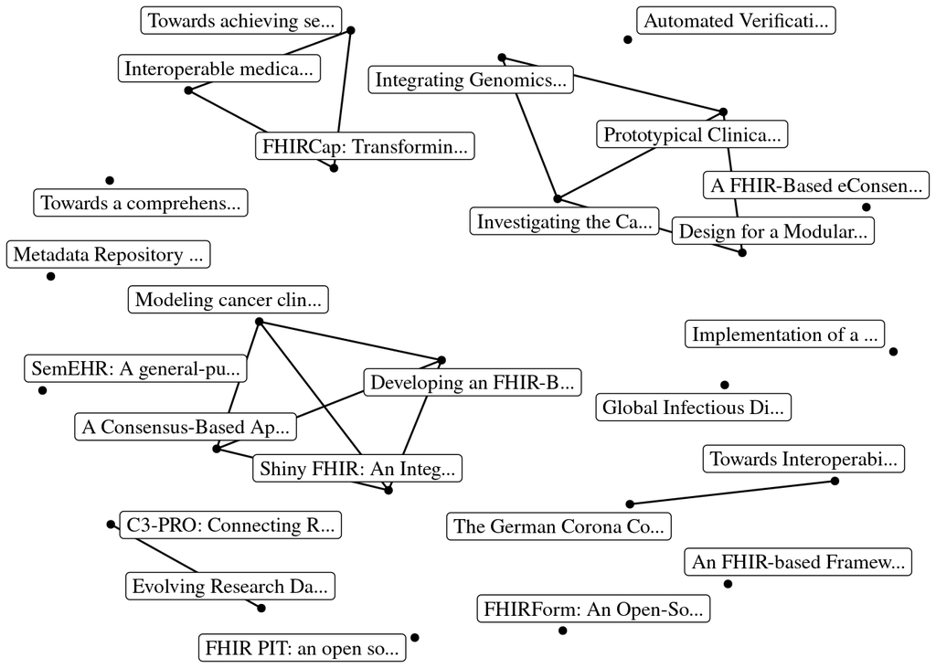

```r
# plot graph
ggraph(paper_network, layout = "with_kk") +
        geom_edge_link() +
        geom_node_point() +
        geom_node_label(aes(label = name), repel = TRUE, family = "serif") +
        theme_void()
```

Each point represents a study. Lines indicate that studies have at least one author in common.

## Network of authors

Create dataframe with authors and their numbers of publications:

```r
# all authors
authors <- unlist(articles_clean$authors_list) %>%
        unique() %>%
        data.frame(author = .) %>%
        mutate(author = as.character(author), publications = 0) %>%
        arrange(author)

# add number of publications per author
for (i in 1:nrow(authors)) {
        a <- authors$author[i]
        for (j in 1:nrow(articles_clean)) {
                authorlist <- unlist(articles_clean$authors_list[j])
                if (a %in% authorlist) {
                        authors$publications[i] <- authors$publications[i] + 1
                }
        }
}
```

Get combinations of authors and count their number of co-authorships:

```r
# construct dataframe with all combinations of authors
author1 = character()
author2 = character()

for (i in 1:(nrow(authors)-1)) {
        for (j in ((i+1):nrow(authors))) {
                author1 <- c(author1, authors$author[i])
                author2 <- c(author2, authors$author[j])
        }

}

# tibble with authors
author_coll <- tibble(author1, author2, collaborations = 0)

# count collaborations for all author combinations
for (i in 1:nrow(author_coll)) {

        a1 <- author_coll$author1[i]
        a2 <- author_coll$author2[i]

        for (j in 1:nrow(articles_clean)) {

                authorlist <- unlist(articles_clean$authors_list[j])

                if (a1 %in% authorlist & a2 %in% authorlist) {
                        author_coll$collaborations[i] <- author_coll$collaborations[i] + 1
                }
        }
}
```

Prepare network object:

```r
# edgelist (authors with collaborations)
edgelist_authors <- author_coll %>%
        filter(collaborations > 0) %>%
        arrange(desc(collaborations))

# create network object
network_authors <- graph_from_data_frame(edgelist_authors, directed = FALSE,
                                         vertices = authors)
```

Plot the network:

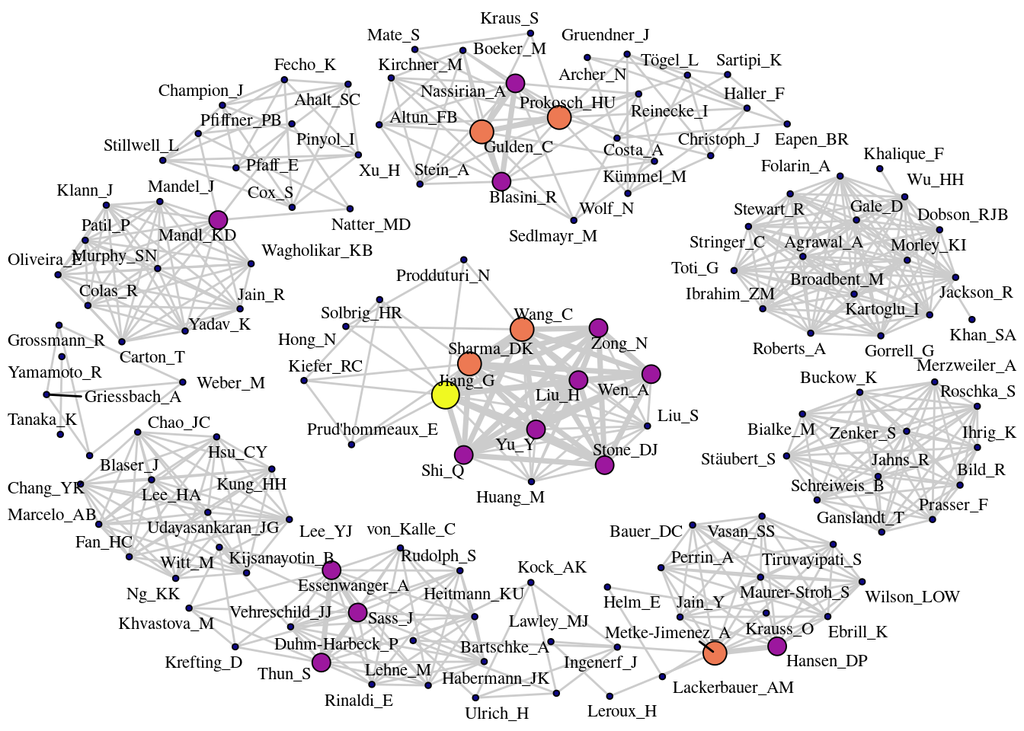

```r
ggraph(network_authors, layout = "kk") +
        geom_edge_link(aes(width = collaborations), color = "grey80") +
        geom_node_point(aes(fill = as.factor(publications), size = publications),
                        shape = 21) +
        #geom_node_point(aes(size = publications)) +
        geom_node_text(aes(label = name), repel = TRUE, size = 3,
                       family = "serif") +
        scale_edge_width(range = c(0.5, 2))+
        scale_fill_viridis_d(option = "C") +
        guides(fill = FALSE, size = FALSE, width = FALSE) +
        theme_void() +
        theme(legend.position = "none")
```

# Figure 1

## Get data and libraries

```r
library(readxl)
articles_figure1 <- read_excel("articles_figure1.xls")
```

```r
attach(articles_figure1)
```

```r
library(data.table)
```

```r
library(ggplot2)
library(dplyr)
```

## Data by year

```r
Pubsyear <- articles_figure1 %>% count(year)
```

## Remove incomplete year 2021

```r
Pubsyear2020 <- Pubsyear[-c(9),]
```

## Plot data

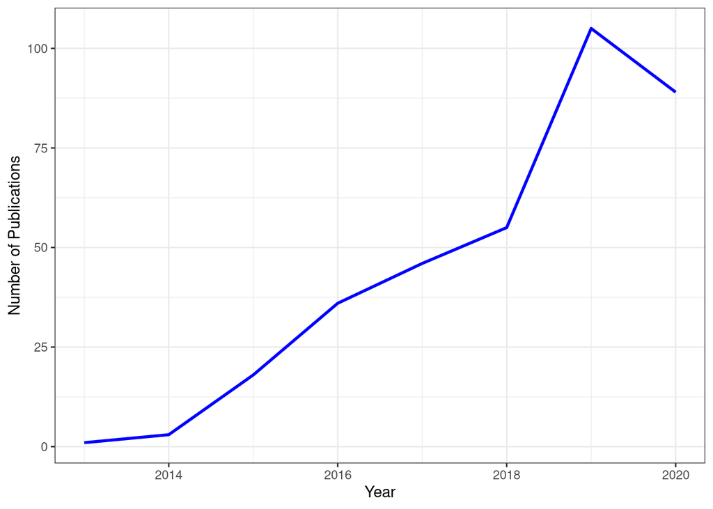

```r
ggplot(data=Pubsyear2020, aes(x=year, y=n))+
  geom_line(colour = "blue", size = 1)+
  xlab("Year")+
  ylab("Number of Publications")+
  theme_bw()
```

# Alternative Figure1

```r
# ggplot(data=excel_data_clean, aes(Year, fill = Country))+
#   geom_histogram(binwidth = 0.4)
```

# Analysis of Excel file

## Data import and cleaning

Import Excel file with included studies (“IncludedStudies2.xlsx”):

```r
excel_data <- read_excel("IncludedStudies2.xlsx")
```

Clean data (keep only variables relevant for analysis, rename variables, reformat, …):

```r
excel_data_clean <- excel_data %>%
  select(Author = `Author (First)`,
         Title,
         Year,
         Country = `Country (according to 1st author affiliation)`,
         Item_mapped_keyword = `Item mapped_keyword`,
         Goal_keyword,
         Other_standards_keyword = `Other standards_keyword`,
         Other_software_keyword = `Other Software_keyword`,
         FHIR_resource_used = `FHIR Resource used`,
         FHIR_extension_used = `FHIR extension used`,
         FHIR_version = `FHIR version`,
         Patients,
         Variables,
         Variables_count,
         Research_category = `Research Category`,
         Medical_area = `Medical Area`,
         Journal,
         Impact_factor = `Impact Factor Research)`,
         Research_area = `Research Area`,
         Clinical_trials = `Clinical Trials`,
         generic,
         SNOMED_CT = `Other standards - SNOMED CT`,
         LOINC = `Other standards - LOINC`,
         ICD_10 = `Other standards - ICD 10`,
         OMOP = `Other standards - OMOP`,
         Other = `Other standards - Other`,
         None = `Other standards - None (nicht angegeben oder nicht verwendet)`) %>%
  mutate(Journal = str_trim(Journal)) %>%
  mutate(Journal = ifelse(Journal %in%  c("Studies in Health technology and informatics", "Studies in Health Technology and Informatics"),
                          "Studies in health technology and informatics", Journal)) %>%
  mutate(Journal = ifelse(Journal == "JMIR medical informatics",
                          "JMIR Medical Informatics", Journal)) %>%
  mutate(Impact_factor = ifelse(Impact_factor %in% c("None", "-"), NA, Impact_factor)) %>%
  mutate(Impact_factor = str_replace(Impact_factor, ",", ".")) %>%
  mutate(Impact_factor = round(as.numeric(Impact_factor), 2)) %>%
  mutate(Country = ifelse(Country == "USA / Switzerland", "USA", Country)) %>%
  mutate(Research_area = ifelse(Research_area == "Clinical trials",
                               "Clinical Trials", Research_area))
```

## Analysis

### Publications per year

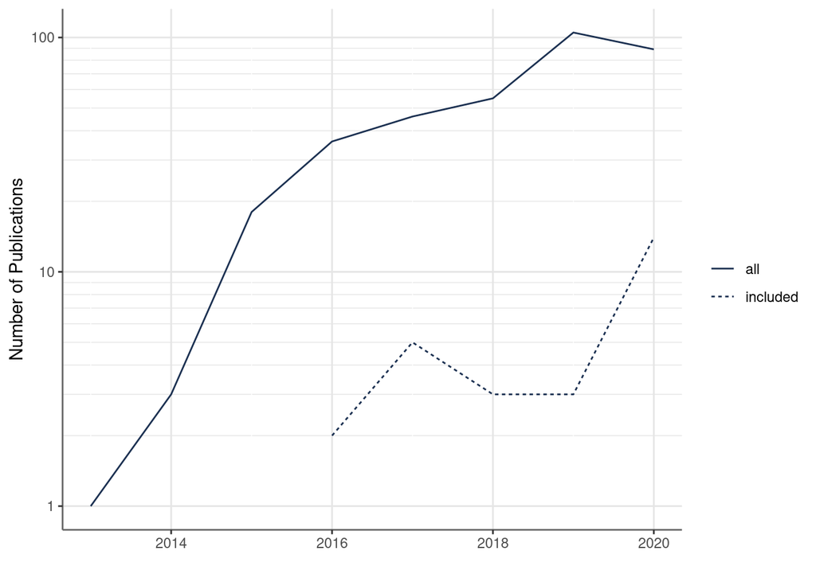

```r
# all articles
pub_all <- read_excel("articles_figure1.xls")

# number of publications per year (all articles)
pub_all_year <- pub_all %>%
  group_by(year) %>%
  summarize(n = n()) %>%
  filter(year < 2021) %>%
  mutate(Articles = "all")

# number of publications per year (included articles)
pub_included_year <- excel_data_clean %>%
  group_by(Year) %>%
  summarize(n = n()) %>%
  filter(Year < 2021) %>%
  mutate(Articles = "included") %>%
  rename(year = Year)

# combine in one data frame
pub_year <- rbind(pub_all_year, pub_included_year)

# plot
ggplot(pub_year) + geom_line(aes(year, n, linetype = Articles),
                             color = "#1b3051") +
  labs(x = "", y = "Number of Publications", linetype = "") +
  scale_y_log10(minor_breaks = c(seq(1,9), seq(10,90,10))) +
  theme(rect = element_blank(),
        axis.line = element_line(color = "grey40"),
        panel.grid.major = element_line(color = "grey90"),
        panel.grid.minor.y = element_line(color = "grey90"))
```

### Countries

The articles originate from the following countries (according to affiliation of first author):

```r
countries <- excel_data_clean %>%
  group_by(Country) %>%
  summarize(N = n()) %>%
  mutate(Percent = N / sum(N) * 100,
         Percent = round(Percent, 1)) %>%
  arrange(desc(N))

knitr::kable(countries)
```

| Country | N | Percent |
| --- | --- | --- |
| Germany | 10 | 35.7 |
| USA | 8 | 28.6 |
| Australia | 3 | 10.7 |
| Austria | 1 | 3.6 |
| Canada | 1 | 3.6 |
| Japan | 1 | 3.6 |
| Pakistan | 1 | 3.6 |
| Switzerland | 1 | 3.6 |
| Taiwan | 1 | 3.6 |
| UK | 1 | 3.6 |

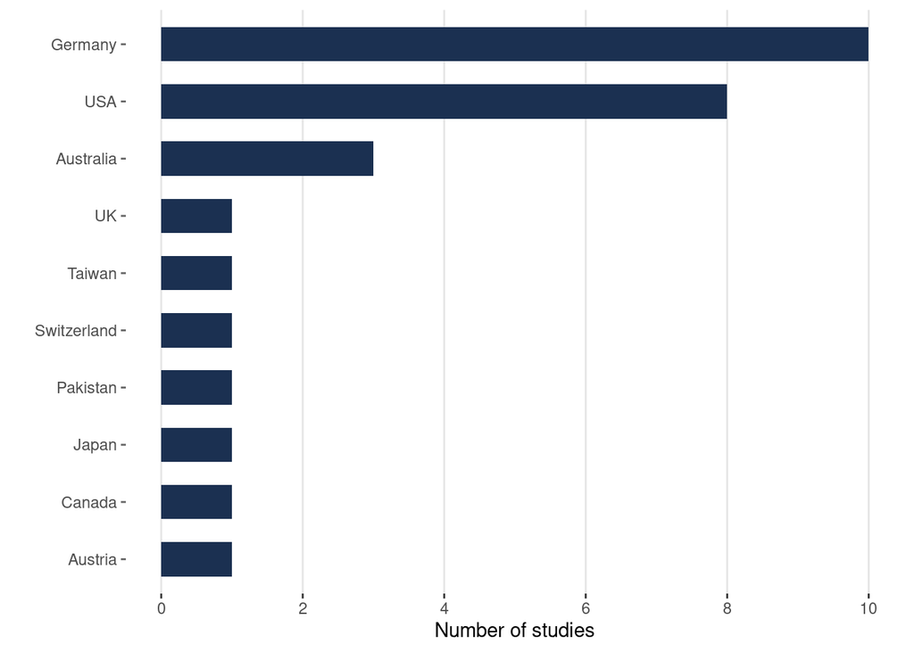

```r
# define theme and colors for barplots
bar_theme <-   theme(rect = element_blank(),
        axis.ticks.y = element_line(color = "grey40"),
        panel.grid.major.x = element_line(color = "grey90"))
bar_color <-  "#1b3051"
bar_width <- 0.6

ggplot(countries) +
  geom_col(aes(reorder(Country, N, sum), N), fill = bar_color,
           width = bar_width) +
  labs(x = "", y = "Number of studies") +
  scale_y_continuous(breaks = seq(0,10,2)) +
  coord_flip() +
  scale_color_manual(values = "#668dcc") +
  bar_theme
```

Map of countries:

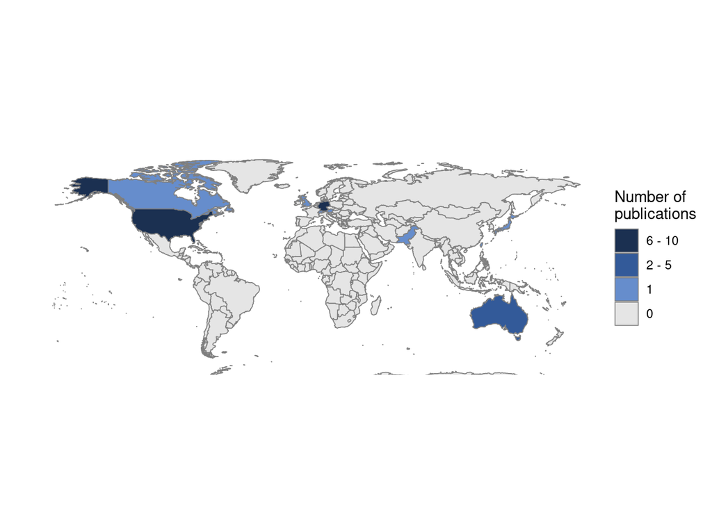

```r
# geographical map
world <- map_data('world')
world_countries <- as.data.frame(unique(world$region))
names(world_countries) <- "Country"

# join map with country data
countries_map <- countries %>%
        right_join(world_countries, by = "Country") %>%
        arrange(desc(N)) %>%
        mutate(category = case_when(
          N == 1 ~ "1",
          N >= 2 & N <= 5 ~ "2 - 5",
          N >= 6 & N <= 10 ~ "6 - 10",
          is.na(N) ~ "0")) %>%
        mutate(category=factor(category, levels = rev(c("0", "1", "2 - 5", "6 - 10"))))

# plot map
ggplot() + geom_map(data = world, map = world,
                 aes(x = long, y = lat, group = group, map_id=region),
                 fill = "grey95", colour="grey70", size=0.3) +
        geom_map(data = countries_map, map=world,
                 aes(fill=category, map_id=Country),
                 colour="grey50", size=0.3) +
        coord_map("rectangular", lat0=0, xlim=c(-180,180), ylim=c(-60, 90)) +
        scale_fill_manual(values=rev(c("grey90", "#668dcc", "#335a99", "#1b3051"))) +
        scale_y_continuous(breaks=c()) +
        scale_x_continuous(breaks=c()) +
        labs(fill="Number of\npublications", title="", x="", y="") +
        theme_minimal()
```

### Journals

The articles were published in the following scientific journals:

```r
journals <- excel_data_clean %>%
  group_by(Journal) %>%
  mutate(N = n()) %>%
  select(Journal, Impact_factor, N) %>%
  distinct() %>%
  ungroup() %>%
  mutate(Percent = N / sum(N) * 100,
         Percent = round(Percent, 1)) %>%
  arrange(desc(N))

knitr::kable(journals)
```

| Journal | Impact_factor | N | Percent |
| --- | --- | --- | --- |
| Studies in health technology and informatics | NA | 10 | 35.7 |
| BMC medical informatics and decision making | 2.32 | 3 | 10.7 |
| JMIR Medical Informatics | 2.58 | 2 | 7.1 |
| AMIA Joint Summits on Translational Science proceedings | NA | 2 | 7.1 |
| Transboundary and emerging diseases | 3.47 | 1 | 3.6 |
| Journal of Translational Medicine | 4.20 | 1 | 3.6 |
| Journal of medical Internet research | 5.03 | 1 | 3.6 |
| 2017 IEEE 11th International Conference on Application of Information and Communication Technologies (AICT) | NA | 1 | 3.6 |
| Journal of medical systems | 3.18 | 1 | 3.6 |
| Journal of biomedical semantics | 1.58 | 1 | 3.6 |
| PLOS One | 2.74 | 1 | 3.6 |
| Journal of the American Medical Informatics Association | 4.46 | 1 | 3.6 |
| JCO clinical cancer informatics | 1.22 | 1 | 3.6 |
| International Journal of Medical Informatics | 3.59 | 1 | 3.6 |
| AMIA Joint Summits on Translational Science | NA | 1 | 3.6 |

### Research category

Articles were grouped into the following research categories:

```r
categories <- excel_data_clean %>%
  group_by(Research_category) %>%
  summarize(N = n()) %>%
  mutate(Percent = N / sum(N) * 100,
         Percent = round(Percent, 1)) %>%
  arrange(desc(N))

knitr::kable(categories)
```

| Research_category | N | Percent |
| --- | --- | --- |
| Data capture | 11 | 39.3 |
| Standardization of data | 7 | 25.0 |
| Analysis | 4 | 14.3 |
| Recruitment | 4 | 14.3 |
| Consent management | 2 | 7.1 |

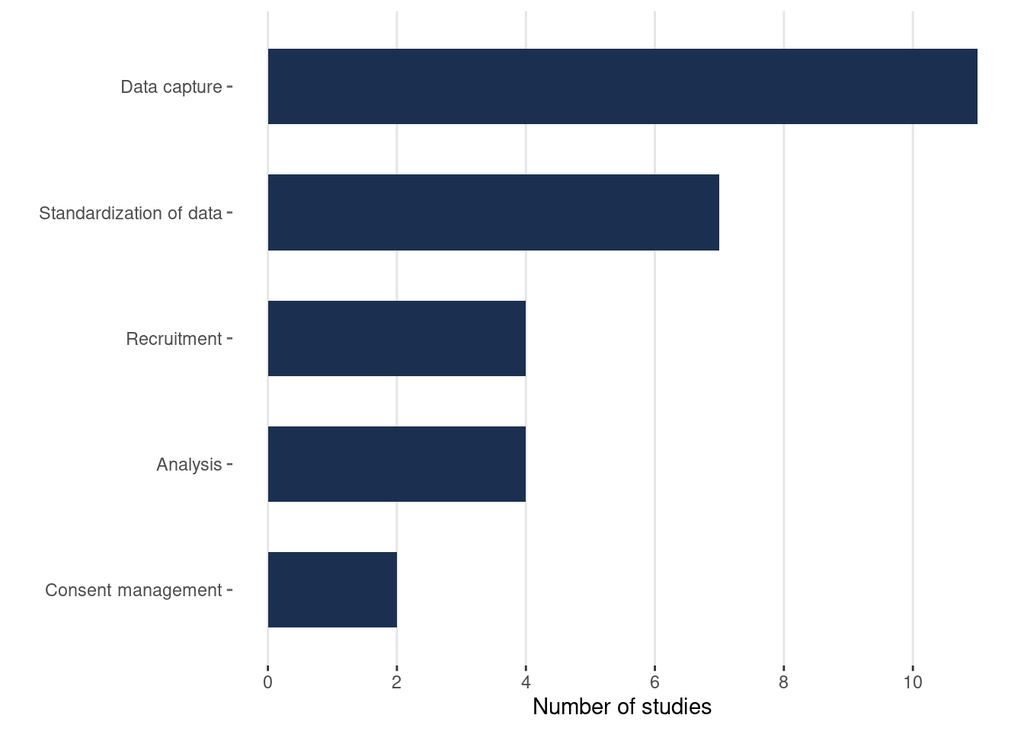

```r
ggplot(categories) + geom_col(aes(reorder(Research_category, N, sum), N),
                              fill = bar_color,
                              width = bar_width) +
  labs(x = "", y = "Number of studies") +
  scale_y_continuous(breaks = seq(0,12,2)) +
  coord_flip() +
  bar_theme
```

Most articles reported generic solutions:

```r
table(excel_data_clean$generic)
```

```
##
##  No Yes
##   4  24
```

### Medical area

Articles were grouped into the following medical areas:

```r
medical_area <- excel_data_clean %>%
  group_by(Medical_area) %>%
  summarize(N = n()) %>%
  mutate(Percent = N / sum(N) * 100,
         Percent = round(Percent, 1)) %>%
  arrange(desc(N))

knitr::kable(medical_area)
```

| Medical_area | N | Percent |
| --- | --- | --- |
| Generic | 15 | 53.6 |
| Infectious Disease | 4 | 14.3 |
| Genomics | 3 | 10.7 |
| Oncology | 3 | 10.7 |
| Environmental health | 1 | 3.6 |
| Neuroimaging research | 1 | 3.6 |
| Pulmonary Hypertension | 1 | 3.6 |

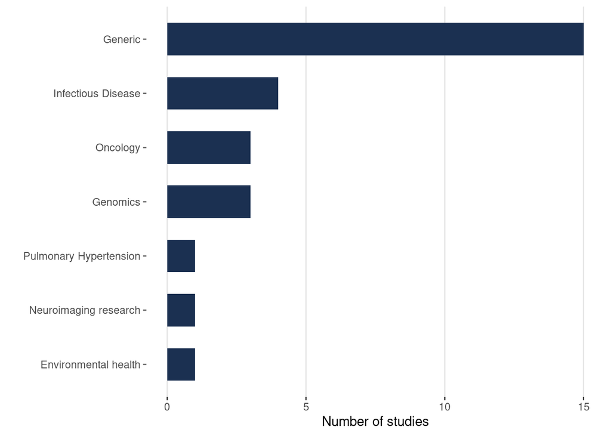

```r
ggplot(medical_area) + geom_col(aes(reorder(Medical_area, N, sum), N),
                                fill = bar_color,
                                width = bar_width) +
  labs(x = "", y = "Number of studies") +
  scale_y_continuous(breaks = seq(0,15,5)) +
  coord_flip() +
  bar_theme
```

### Research area

Articles were grouped into the following research areas:

```r
research_area <- excel_data_clean %>%
  group_by(Research_area) %>%
  summarize(N = n()) %>%
  mutate(Percent = N / sum(N) * 100,
         Percent = round(Percent, 1)) %>%
  arrange(desc(N))

knitr::kable(research_area)
```

| Research_area | N | Percent |
| --- | --- | --- |
| Clinical Research | 13 | 46.4 |
| Clinical Trials | 9 | 32.1 |
| Public Health/ Epidemiological Studies | 3 | 10.7 |
| Research not specified | 3 | 10.7 |

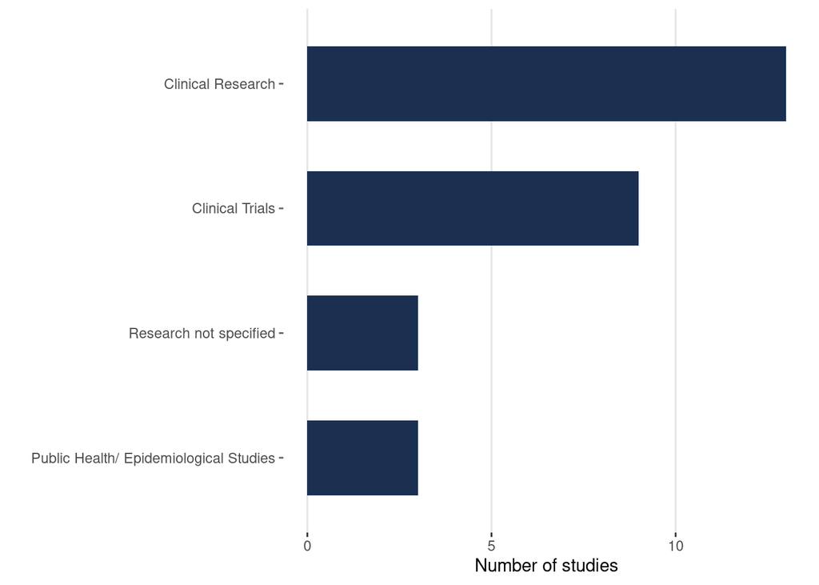

```r
ggplot(research_area) +
  geom_col(aes(reorder(Research_area, N, sum), N),
           fill = bar_color,
           width = bar_width) +
  labs(x = "", y = "Number of studies") +
  scale_y_continuous(breaks = seq(0,15,5)) +
  coord_flip() +
  bar_theme
```

Plot clinical trials as part of clinical research:

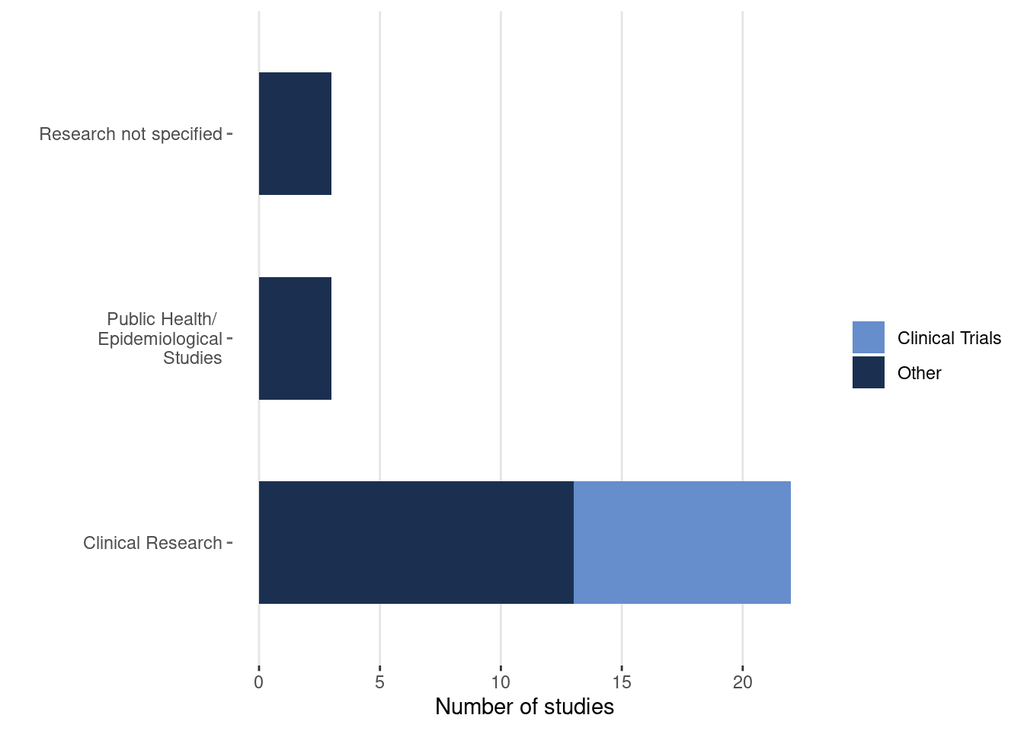

```r
plot_data <- excel_data_clean %>%
  mutate(Clinical_trials = ifelse(Research_area == "Clinical Trials",
                                  "Clinical Trials", "Other")) %>%
  mutate(Research_area = ifelse(Research_area == "Clinical Trials",
                                "Clinical Research", Research_area)) %>%
  mutate(Research_area = ifelse(Research_area == "Public Health/ Epidemiological Studies", "Public Health/ \n Epidemiological\n Studies", Research_area))

ggplot(plot_data) +
  geom_bar(aes(Research_area,
               fill = Clinical_trials), width = bar_width) +
  labs(x = "", y = "Number of studies", fill = "") +
  scale_y_continuous(breaks = seq(0,25,5)) +
  scale_fill_manual(values=c("#668dcc", "#1b3051")) +
  coord_flip() +
  bar_theme
```

### Standards

The following other standards and terminologies were used in the studies:

```r
standards <- excel_data_clean %>%
  select(SNOMED_CT:None) %>%
  gather("Standard", "used") %>%
  group_by(Standard) %>%
  summarize(N = sum(used)) %>%
  mutate(Percent = N / nrow(excel_data_clean) * 100,
         Percent = round(Percent, 1)) %>%
  arrange(desc(N))

knitr::kable(standards)
```

| Standard | N | Percent |
| --- | --- | --- |
| None | 14 | 50.0 |
| Other | 9 | 32.1 |
| LOINC | 8 | 28.6 |
| SNOMED_CT | 8 | 28.6 |
| ICD_10 | 6 | 21.4 |
| OMOP | 3 | 10.7 |

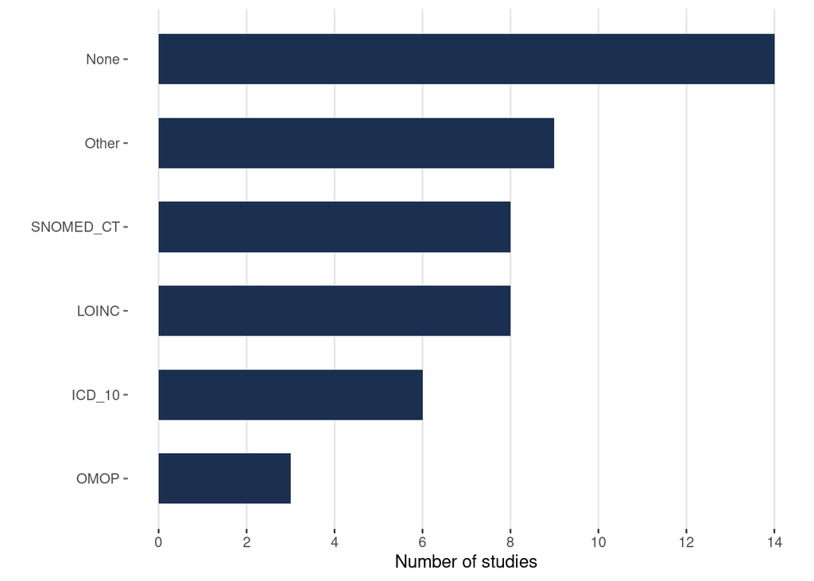

```r
ggplot(standards) + geom_col(aes(reorder(Standard, N, sum), N),
                             fill = bar_color,
                             width = bar_width) +
  labs(x = "", y = "Number of studies") +
  scale_y_continuous(breaks = seq(0,14,2)) +
  coord_flip() +
  bar_theme
```

The “Other” category is relatively large. Maybe investigate this category in more detail.

### Goals

This section analyzes the most common keywords describing the goals of the articles.

Load tidytext package and get word frequencies of all words in Goal_keyword variable:

```r
library(tidytext)

# define some stop words to be excluded
stop_words <- c("of", "and", "for", "from", "a", "an", "between",
                "across", "on", "the", "to", "in", "into", "with",
                "as", "or", "other", "such", "via")

goal_keywords <- excel_data_clean %>%
  select(Goal_keyword) %>%
  unnest_tokens(word, Goal_keyword, to_lower = TRUE) %>%
  filter(!(word %in% stop_words)) %>%
  group_by(word) %>%
  summarize(freq = n()) %>%
  arrange(desc(freq))
```

The wordcloud shows the most common words mentioned as keywords:

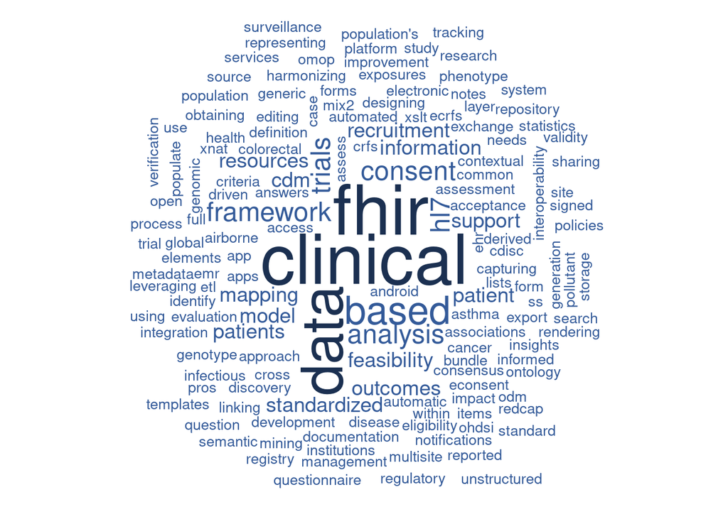

```r
library(wordcloud)
wordcloud(words = goal_keywords$word, freq = goal_keywords$freq, min.freq = 1, max.words=150, random.order=FALSE, rot.per=0.10,
          colors=c("#335a99", "#1b3051"))
```

Note that there are still some typos shown in the wordcloud. (Correct all typos in the final Excel file before analysis.)